# Module 3: Statistical Foundations for ExWAS

## Overview

This module covers the statistical machinery behind ExWAS:

1. Survey sampling concepts
2. `svydesign()` and `svyglm()` vs. `lm()`
3. Multivariate regression
4. Log transformation of skewed exposures
5. Z-score standardization
6. Multiple testing: Bonferroni vs. FDR
7. Confounding and DAGs
8. R-squared and delta R-squared

## Why Special Statistics for NHANES?

NHANES uses **complex survey sampling** — not simple random sampling:

- Certain subpopulations are **oversampled** (e.g., minorities, elderly)
- Participants within the same PSU/stratum are **correlated**
- Each participant has a **sampling weight** reflecting how many people they represent

**Consequence**: Standard `lm()` produces biased standard errors and invalid p-values.

## The Survey Package

The `survey` package in R handles complex survey designs:

```r
library(survey)
```

Two key functions:

1. `svydesign()` — declare the survey design
2. `svyglm()` — fit regression models accounting for the design

## Creating a Survey Design Object

```r
dsn <- svydesign(
  ids = ~SDMVPSU,       # primary sampling units
  strata = ~SDMVSTRA,   # strata
  weights = ~WTMEC2YR,  # sampling weights
  nest = TRUE,          # PSUs nested within strata
  data = NHData.train
)
```

- **weights**: how much each individual “counts” (inverse of selection probability)
- **ids**: clusters of correlated individuals (PSUs)
- **strata**: groups within which PSUs are sampled

## svyglm() vs. lm(): Side by Side

**Survey-weighted regression:**

```r
mod_svy <- svyglm(BMXBMI ~ RIDAGEYR, dsn)
```

**Ordinary regression (ignoring survey design):**

```r
mod_lm <- lm(BMXBMI ~ RIDAGEYR, data = NHData.train)
```

## Comparing Estimates

```r
bind_rows(
  tidy(mod_svy) %>% mutate(method = "svyglm"),
  tidy(mod_lm) %>% mutate(method = "lm")
) %>%
  select(method, term, estimate, std.error, p.value) %>%
  kable(digits = 4) %>% kable_styling(font_size = 10)
```

| method | term | estimate | std.error | p.value |
| --- | --- | --- | --- | --- |
| svyglm | (Intercept) | 20.6623 | 0.1447 | 0 |
| svyglm | RIDAGEYR | 0.1455 | 0.0034 | 0 |
| lm | (Intercept) | 20.4280 | 0.0778 | 0 |
| lm | RIDAGEYR | 0.1416 | 0.0020 | 0 |

Note: coefficients may be similar, but **standard errors** differ — and that affects p-values.

## When Does It Matter?

- For **point estimates** (coefficients), the difference is often modest
- For **inference** (p-values, confidence intervals), the difference can be substantial
- **Always use survey-weighted methods** when analyzing NHANES for valid inference

## Multivariate Regression

Including multiple predictors in a single model:

\[\text{BMI} = \alpha + \beta_1 \cdot \text{Age} + \beta_2 \cdot \text{Sex} + \beta_3 \cdot \text{Race} + \beta_4 \cdot \text{Income} + \epsilon\]

```r
mod_multi <- svyglm(BMXBMI ~ RIDAGEYR + male +
                    black + mexican + other_hispanic + other_eth +
                    INDFMPIR, dsn)
```

## Multivariate Results

```r
tidy(mod_multi) %>%
  select(term, estimate, std.error, p.value) %>%
  kable(digits = 4) %>% kable_styling(font_size = 9)
```

| term | estimate | std.error | p.value |
| --- | --- | --- | --- |
| (Intercept) | 20.4261 | 0.2579 | 0.0000 |
| RIDAGEYR | 0.1524 | 0.0034 | 0.0000 |
| male | -0.2090 | 0.1329 | 0.1302 |
| black | 1.5605 | 0.1810 | 0.0000 |
| mexican | 0.9928 | 0.1902 | 0.0000 |
| other_hispanic | 0.5532 | 0.2813 | 0.0620 |
| other_eth | -0.0129 | 0.6124 | 0.9833 |
| INDFMPIR | -0.0620 | 0.0569 | 0.2879 |

## Interpreting Multivariate Coefficients

Each coefficient represents the association **holding all other variables constant**:

- `RIDAGEYR`: change in BMI per 1-year increase in age, adjusted for sex, race, income
- `male`: difference in BMI for males vs. females, adjusted for age, race, income
- `black`, `mexican`, etc.: difference in BMI relative to white (reference group)

## Exploring an Exposure: Blood Lead

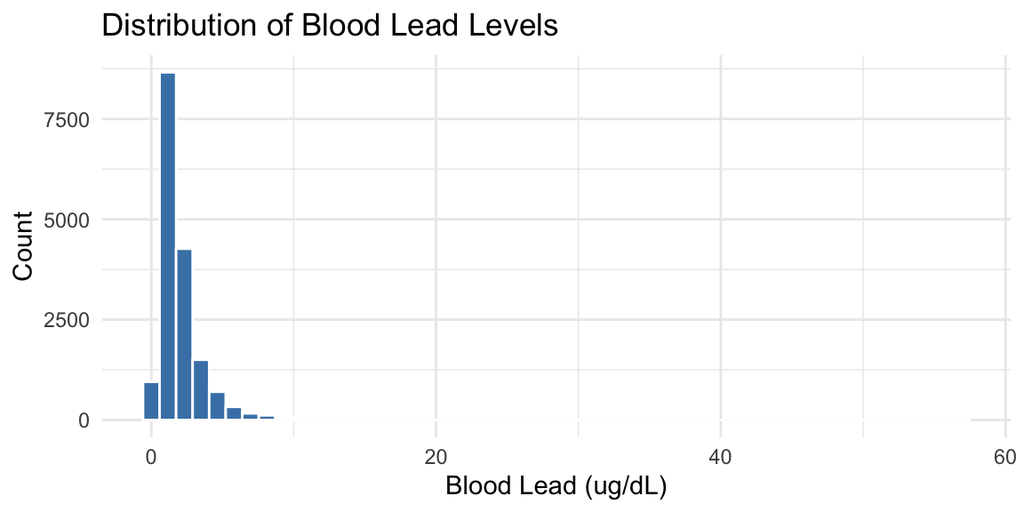

```r
ggplot(NHData.train, aes(x = LBXBPB)) +
  geom_histogram(bins = 50, fill = "steelblue", color = "white") +
  labs(x = "Blood Lead (ug/dL)", y = "Count",
       title = "Distribution of Blood Lead Levels") +
  theme_minimal()
```

The distribution is **right-skewed** — most values are low with a long right tail.

## Why Log-Transform?

- Many exposure biomarkers have **right-skewed** distributions
- Log transformation makes the distribution more **symmetric**
- Improves linear model assumptions (normality of residuals)
- Common practice in environmental epidemiology

## Log-Transforming Lead

```r
NHData.train <- NHData.train %>%
  mutate(lead_logged = log(LBXBPB + 0.001))
```

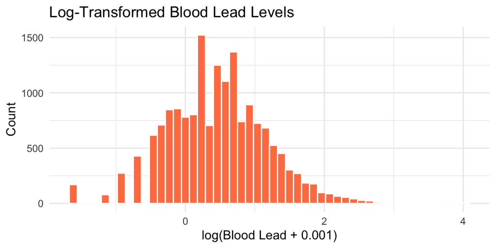

```r
ggplot(NHData.train, aes(x = lead_logged)) +
  geom_histogram(bins = 50, fill = "coral", color = "white") +
  labs(x = "log(Blood Lead + 0.001)", y = "Count",
       title = "Log-Transformed Blood Lead Levels") +
  theme_minimal()
```

## Why Add 0.001?

- Some exposure values may be **zero** (below detection limit)
- \(\log(0) = -\infty\), so we add a small constant
- `log(LBXBPB + 0.001)` ensures all values are defined
- The constant (0.001) is small enough to not affect non-zero values substantially

## Interpreting Log-Transformed Coefficients

```r
# Rebuild design with updated data
dsn <- svydesign(ids = ~SDMVPSU, strata = ~SDMVSTRA,
                 weights = ~WTMEC2YR, nest = TRUE, data = NHData.train)
mod_log <- svyglm(LBXGLU ~ log(LBXBPB + 0.001), dsn)
tidy(mod_log) %>% kable(digits = 3) %>% kable_styling()
```

| term | estimate | std.error | statistic | p.value |
| --- | --- | --- | --- | --- |
| (Intercept) | 98.294 | 0.628 | 156.535 | 0 |
| log(LBXBPB + 0.001) | 4.322 | 0.664 | 6.511 | 0 |

A 1-unit change in log(exposure) corresponds to a ~2.7-fold change in the raw exposure (since \(e^1 \approx 2.72\)).

## Z-Score Standardization (Scaling)

Different exposures have different units (ug/dL, ng/mL, etc.). To compare across exposures:

\[z = \frac{x - \bar{x}}{s_x}\]

```r
NHData.train <- NHData.train %>%
  mutate(lead_scaled = scale(log(LBXBPB + 0.001)))

NHData.train %>%
  summarize(
    raw_mean = mean(log(LBXBPB + 0.001), na.rm = TRUE),
    raw_sd = sd(log(LBXBPB + 0.001), na.rm = TRUE),
    scaled_mean = mean(lead_scaled, na.rm = TRUE),
    scaled_sd = sd(lead_scaled, na.rm = TRUE)
  ) %>%
  kable(digits = 3) %>% kable_styling()
```

| raw_mean | raw_sd | scaled_mean | scaled_sd |
| --- | --- | --- | --- |
| 0.46 | 0.713 | 0 | 1 |

## Why Standardize?

After scaling:

- Mean = 0, SD = 1
- Coefficients represent the change in outcome per **1 SD change** in the exposure
- All exposure associations are on the **same scale**
- Essential for comparing effect sizes across different exposures in ExWAS

## The ExWAS Model

For each exposure \(E_j\), we fit:

\[\text{Phenotype} = \alpha + \beta_j \cdot \text{scale}(\log(E_j + 0.001)) + \gamma_1 \cdot \text{Age} + \gamma_2 \cdot \text{Sex} + \gamma_3 \cdot \text{Race} + \gamma_4 \cdot \text{Income} + \epsilon\]

- \(\beta_j\): effect of a 1 SD change in log-exposure on the phenotype
- Adjusted for confounders (age, sex, race, income)

## Multiple Testing Problem

When testing \(m\) hypotheses simultaneously:

- At \(\alpha = 0.05\), we expect \(0.05 \times m\) false positives by chance
- With \(m = 160\) exposures: ~8 false positives expected
- We need **multiple testing correction**

## Bonferroni Correction

The simplest approach — divide \(\alpha\) by the number of tests:

\[\alpha_{\text{Bonf}} = \frac{\alpha}{m} = \frac{0.05}{160} = 0.000313\]

- Controls the **Family-Wise Error Rate (FWER)**
- Probability of **any** false positive \(\leq \alpha\)
- Very **conservative** — may miss true associations

## Benjamini-Hochberg FDR

A less conservative approach controlling the **False Discovery Rate**:

1. Rank p-values from smallest to largest: \(p_{(1)} \leq p_{(2)} \leq \cdots \leq p_{(m)}\)
2. Find the largest \(k\) such that \(p_{(k)} \leq \frac{k}{m} \cdot \alpha\)
3. Reject all hypotheses \(H_{(1)}, \ldots, H_{(k)}\)
- Controls the **expected proportion of false discoveries** among rejected hypotheses
- Less conservative than Bonferroni
- Preferred for ExWAS

## FDR in R

```r
# Simulated p-values for demonstration
set.seed(42)
pvalues <- c(runif(10, 0, 0.001), runif(150, 0, 1))  # 10 "real" + 150 null

# Bonferroni
bonf_adjusted <- p.adjust(pvalues, method = "bonferroni")

# Benjamini-Hochberg FDR
fdr_adjusted <- p.adjust(pvalues, method = "BH")

tibble(
  raw_p = sort(pvalues)[1:5],
  bonferroni = sort(bonf_adjusted)[1:5],
  fdr = sort(fdr_adjusted)[1:5]
) %>% kable(digits = 6) %>% kable_styling()
```

| raw_p | bonferroni | fdr |
| --- | --- | --- |
| 0.000135 | 0.021547 | 0.01363 |
| 0.000239 | 0.038223 | 0.01363 |
| 0.000286 | 0.045782 | 0.01363 |
| 0.000519 | 0.083055 | 0.01363 |
| 0.000642 | 0.102679 | 0.01363 |

## Bonferroni vs. FDR: Comparison

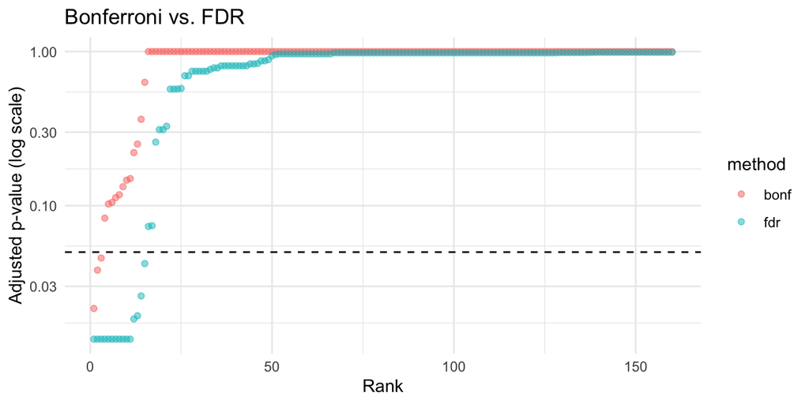

```r
tibble(raw = sort(pvalues), bonf = sort(bonf_adjusted), fdr = sort(fdr_adjusted),
       rank = 1:length(pvalues)) %>%
  pivot_longer(cols = c(bonf, fdr), names_to = "method", values_to = "adjusted_p") %>%
  ggplot(aes(x = rank, y = adjusted_p, color = method)) +
  geom_point(alpha = 0.5) +
  geom_hline(yintercept = 0.05, linetype = "dashed") +
  scale_y_log10() +
  labs(x = "Rank", y = "Adjusted p-value (log scale)", title = "Bonferroni vs. FDR") +
  theme_minimal()
```

## Confounding

A **confounder** C is a variable that:

1. Is associated with the exposure (E)
2. Is associated with the outcome (P)
3. Is NOT on the causal path from E to P

If we don’t adjust for C, the E-P association is **biased**.

## Directed Acyclic Graphs (DAGs)

DAGs represent causal relationships:

```
     C
    / \
   v   v
   E   P
```

- C → E: confounder causes exposure level
- C → P: confounder causes phenotype
- Without adjusting for C, we see a spurious E-P association

Example: **Age** (C) affects both **lead exposure** (E) and **BMI** (P).

## Adjusting for Confounders

In our ExWAS model, we adjust for:

| Confounder | Why? |
| --- | --- |
| Age | Affects both exposure levels and health outcomes |
| Sex | Biological differences in metabolism and exposure |
| Race/Ethnicity | Sociostructural differences in exposure and health |
| Income (INDFMPIR) | Socioeconomic factors affect exposure and health |

## The Confounding Problem in ExWAS

A fundamental limitation of screening approaches like ExWAS:

**Each exposure-phenotype pair has a different confounding structure** — but we apply the **same covariate set** to all tests.

```
Lead → BMI:     confounders = age, SES, housing, occupation
Vitamin D → BMI: confounders = age, SES, physical activity, sun exposure
Cotinine → BMI:  confounders = age, SES, alcohol use, diet quality
```

There is no single DAG for the exposome — there are **hundreds of DAGs**, one per association.

## Why This Matters

Using a “one-size-fits-all” covariate set means:

- **Under-adjustment**: missing a key confounder for some associations → false positives
- **Over-adjustment**: conditioning on a collider or descendant of the exposure → bias
- **Heterogeneous bias**: the direction and magnitude of bias differs across exposures

Example: Adjusting for BMI when testing diet → glucose may **block a causal path** (over-adjust), while failing to adjust for physical activity when testing vitamin D → BMI may **leave confounding open** (under-adjust).

## Implications for ExWAS

This does not invalidate ExWAS — but it means:

1. ExWAS results are **hypothesis-generating**, not causal claims
2. The same covariate set is a practical necessity, not an ideal
3. **Sensitivity analysis** across multiple adjustment models (Module 4) helps assess robustness
4. Top hits should be followed up with **exposure-specific DAGs** and targeted analyses
5. Advanced methods can help mitigate this bias (Module 7)

## R-Squared (\(R^2\))

\(R^2\) measures the proportion of variance in the outcome explained by the model:

\[R^2 = 1 - \frac{SS_{\text{res}}}{SS_{\text{tot}}}\]

```r
mod_base <- lm(BMXBMI ~ RIDAGEYR + male +
               black + mexican + other_hispanic + other_eth +
               INDFMPIR, data = NHData.train)
glance(mod_base) %>%
  select(r.squared, adj.r.squared) %>%
  kable(digits = 4) %>% kable_styling()
```

| r.squared | adj.r.squared |
| --- | --- |
| 0.2343 | 0.234 |

## Delta R-Squared (\(\Delta R^2\))

How much **additional** variance does the exposure explain beyond confounders?

\[\Delta R^2 = R^2_{\text{full}} - R^2_{\text{base}}\]

```r
# Base model (confounders only)
r2_base <- summary(lm(BMXBMI ~ RIDAGEYR + male +
                      black + mexican + other_hispanic + other_eth +
                      INDFMPIR,
                      data = NHData.train))$r.squared

# Full model (confounders + exposure)
r2_full <- summary(lm(BMXBMI ~ scale(log(LBXBPB + 0.001)) +
                      RIDAGEYR + male +
                      black + mexican + other_hispanic + other_eth +
                      INDFMPIR,
                      data = NHData.train))$r.squared

tibble(r2_base = r2_base, r2_full = r2_full,
       delta_r2 = r2_full - r2_base) %>%
  kable(digits = 5) %>% kable_styling()
```

| r2_base | r2_full | delta_r2 |
| --- | --- | --- |
| 0.23431 | 0.25109 | 0.01678 |

## Putting It Together: The ExWAS Pipeline

1. **Set up** survey design with `svydesign()`
2. **For each exposure**: log-transform and standardize
3. **Fit** `svyglm()` adjusting for confounders
4. **Collect** estimates, standard errors, p-values
5. **Correct** p-values with Benjamini-Hochberg FDR
6. **Compare** \(\Delta R^2\) across exposures
7. **Replicate** in independent dataset

## Summary

- **Survey-weighted methods** (`svydesign`, `svyglm`) are essential for NHANES
- **Log-transform** skewed exposure distributions
- **Standardize** (Z-score) to compare effect sizes across exposures
- **Multiple testing correction**: FDR preferred over Bonferroni for ExWAS
- **Confounders** must be identified and adjusted for (use DAGs)
- **Confounders differ per association** — a major limitation of one-size-fits-all screening
- **\(\Delta R^2\)** quantifies the unique contribution of each exposure

## What’s Next?

**Module 4: The nhanespewas Package**

- Installing and connecting to the nhanespewas database
- Exploring exposure and phenotype catalogs
- Understanding adjustment models
- First ExWAS with `pe_flex_adjust()`